# exploration

```python
import numpy as np
import pandas as pd
import matplotlib.pyplot as plt
import seaborn as sb
%matplotlib inline
```

```python
df = pd.read_csv('prosperLoanData.csv')
pd.set_option('display.max_columns', None)

base_color = sb.color_palette()[0]
```

## Dataset Overview

Data name: Loan Data from Prosper.

This data set contains 113,937 loans with 81 variables on each loan, including loan amount, borrower rate (or interest rate), current loan status, borrower income, and many others.

```python
df.head(4)
```

|  | ListingKey | ListingNumber | ListingCreationDate | CreditGrade | Term | LoanStatus | ClosedDate | BorrowerAPR | BorrowerRate | LenderYield | EstimatedEffectiveYield | EstimatedLoss | EstimatedReturn | ProsperRating (numeric) | ProsperRating (Alpha) | ProsperScore | ListingCategory (numeric) | BorrowerState | Occupation | EmploymentStatus | EmploymentStatusDuration | IsBorrowerHomeowner | CurrentlyInGroup | GroupKey | DateCreditPulled | CreditScoreRangeLower | CreditScoreRangeUpper | FirstRecordedCreditLine | CurrentCreditLines | … |
| --- | --- | --- | --- | --- | --- | --- | --- | --- | --- | --- | --- | --- | --- | --- | --- | --- | --- | --- | --- | --- | --- | --- | --- | --- | --- | --- | --- | --- | --- | --- |
| 0 | 1021339766868145413AB3B | 193129 | 2007-08-26 19:09:29.263000000 | C | 36 | Completed | 2009-08-14 00:00:00 | 0.16516 | 0.1580 | 0.1380 | NaN | NaN | NaN | NaN | NaN | NaN | 0 | CO | Other | Self-employed | 2.0 | True | True | NaN | 2007-08-26 18:41:46.780000000 | 640.0 | 659.0 | 2001-10-11 00:00:00 | 5.0 | … |
| 1 | 10273602499503308B223C1 | 1209647 | 2014-02-27 08:28:07.900000000 | NaN | 36 | Current | NaN | 0.12016 | 0.0920 | 0.0820 | 0.0796 | 0.0249 | 0.0547 | 6.0 | A | 7.0 | 2 | CO | Professional | Employed | 44.0 | False | False | NaN | 2014-02-27 08:28:14 | 680.0 | 699.0 | 1996-03-18 00:00:00 | 14.0 | … |
| 2 | 0EE9337825851032864889A | 81716 | 2007-01-05 15:00:47.090000000 | HR | 36 | Completed | 2009-12-17 00:00:00 | 0.28269 | 0.2750 | 0.2400 | NaN | NaN | NaN | NaN | NaN | NaN | 0 | GA | Other | Not available | NaN | False | True | 783C3371218786870A73D20 | 2007-01-02 14:09:10.060000000 | 480.0 | 499.0 | 2002-07-27 00:00:00 | NaN | … |
| 3 | 0EF5356002482715299901A | 658116 | 2012-10-22 11:02:35.010000000 | NaN | 36 | Current | NaN | 0.12528 | 0.0974 | 0.0874 | 0.0849 | 0.0249 | 0.0600 | 6.0 | A | 9.0 | 16 | GA | Skilled Labor | Employed | 113.0 | True | False | NaN | 2012-10-22 11:02:32 | 800.0 | 819.0 | 1983-02-28 00:00:00 | 5.0 | … |

```python
df.dtypes
```

```
ListingKey                      object
ListingNumber                    int64
ListingCreationDate             object
CreditGrade                     object
Term                             int64
                                ...
PercentFunded                  float64
Recommendations                  int64
InvestmentFromFriendsCount       int64
InvestmentFromFriendsAmount    float64
Investors                        int64
Length: 81, dtype: object
```

```python
df.describe()
```

|  | ListingNumber | Term | BorrowerAPR | BorrowerRate | LenderYield | EstimatedEffectiveYield | EstimatedLoss | EstimatedReturn | ProsperRating (numeric) | ProsperScore | ListingCategory (numeric) | EmploymentStatusDuration | CreditScoreRangeLower | CreditScoreRangeUpper | CurrentCreditLines | OpenCreditLines | TotalCreditLinespast7years | OpenRevolvingAccounts | OpenRevolvingMonthlyPayment | InquiriesLast6Months | TotalInquiries | CurrentDelinquencies | AmountDelinquent | DelinquenciesLast7Years | PublicRecordsLast10Years | PublicRecordsLast12Months | RevolvingCreditBalance | BankcardUtilization | AvailableBankcardCredit | … |
| --- | --- | --- | --- | --- | --- | --- | --- | --- | --- | --- | --- | --- | --- | --- | --- | --- | --- | --- | --- | --- | --- | --- | --- | --- | --- | --- | --- | --- | --- | --- |
| count | 1.139370e+05 | 113937.000000 | 113912.000000 | 113937.000000 | 113937.000000 | 84853.000000 | 84853.000000 | 84853.000000 | 84853.000000 | 84853.000000 | 113937.000000 | 106312.000000 | 113346.000000 | 113346.000000 | 106333.000000 | 106333.000000 | 113240.000000 | 113937.00000 | 113937.000000 | 113240.000000 | 112778.000000 | 113240.000000 | 106315.000000 | 112947.000000 | 113240.000000 | 106333.000000 | 1.063330e+05 | 106333.000000 | 106393.000000 | … |
| mean | 6.278857e+05 | 40.830248 | 0.218828 | 0.192764 | 0.182701 | 0.168661 | 0.080306 | 0.096068 | 4.072243 | 5.950067 | 2.774209 | 96.071582 | 685.567731 | 704.567731 | 10.317192 | 9.260164 | 26.754539 | 6.96979 | 398.292161 | 1.435085 | 5.584405 | 0.592052 | 984.507059 | 4.154984 | 0.312646 | 0.015094 | 1.759871e+04 | 0.561309 | 11210.225447 | … |
| std | 3.280762e+05 | 10.436212 | 0.080364 | 0.074818 | 0.074516 | 0.068467 | 0.046764 | 0.030403 | 1.673227 | 2.376501 | 3.996797 | 94.480605 | 66.458275 | 66.458275 | 5.457866 | 5.022644 | 13.637871 | 4.63097 | 447.159711 | 2.437507 | 6.429946 | 1.978707 | 7158.270157 | 10.160216 | 0.727868 | 0.154092 | 3.293640e+04 | 0.317918 | 19818.361309 | … |
| min | 4.000000e+00 | 12.000000 | 0.006530 | 0.000000 | -0.010000 | -0.182700 | 0.004900 | -0.182700 | 1.000000 | 1.000000 | 0.000000 | 0.000000 | 0.000000 | 19.000000 | 0.000000 | 0.000000 | 2.000000 | 0.00000 | 0.000000 | 0.000000 | 0.000000 | 0.000000 | 0.000000 | 0.000000 | 0.000000 | 0.000000 | 0.000000e+00 | 0.000000 | 0.000000 | … |
| 25% | 4.009190e+05 | 36.000000 | 0.156290 | 0.134000 | 0.124200 | 0.115670 | 0.042400 | 0.074080 | 3.000000 | 4.000000 | 1.000000 | 26.000000 | 660.000000 | 679.000000 | 7.000000 | 6.000000 | 17.000000 | 4.00000 | 114.000000 | 0.000000 | 2.000000 | 0.000000 | 0.000000 | 0.000000 | 0.000000 | 0.000000 | 3.121000e+03 | 0.310000 | 880.000000 | … |
| 50% | 6.005540e+05 | 36.000000 | 0.209760 | 0.184000 | 0.173000 | 0.161500 | 0.072400 | 0.091700 | 4.000000 | 6.000000 | 1.000000 | 67.000000 | 680.000000 | 699.000000 | 10.000000 | 9.000000 | 25.000000 | 6.00000 | 271.000000 | 1.000000 | 4.000000 | 0.000000 | 0.000000 | 0.000000 | 0.000000 | 0.000000 | 8.549000e+03 | 0.600000 | 4100.000000 | … |
| 75% | 8.926340e+05 | 36.000000 | 0.283810 | 0.250000 | 0.240000 | 0.224300 | 0.112000 | 0.116600 | 5.000000 | 8.000000 | 3.000000 | 137.000000 | 720.000000 | 739.000000 | 13.000000 | 12.000000 | 35.000000 | 9.00000 | 525.000000 | 2.000000 | 7.000000 | 0.000000 | 0.000000 | 3.000000 | 0.000000 | 0.000000 | 1.952100e+04 | 0.840000 | 13180.000000 | … |
| max | 1.255725e+06 | 60.000000 | 0.512290 | 0.497500 | 0.492500 | 0.319900 | 0.366000 | 0.283700 | 7.000000 | 11.000000 | 20.000000 | 755.000000 | 880.000000 | 899.000000 | 59.000000 | 54.000000 | 136.000000 | 51.00000 | 14985.000000 | 105.000000 | 379.000000 | 83.000000 | 463881.000000 | 99.000000 | 38.000000 | 20.000000 | 1.435667e+06 | 5.950000 | 646285.000000 | … |

```python
df.shape
```

```
(113937, 81)
```

# Exploratory Data

## Univariate Exploration

Main variable of interest:

- LoanStatus(loan’s outcome)
- BorrowerAPR
- BorrowerRate

**LoanStatus**

How are loan status distributed?

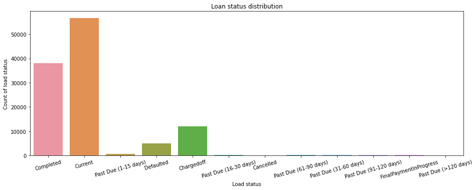

```python
fig = plt.figure()
ax = fig.add_axes([.0, .0, 2, 1])
sb.countplot(data=df, x='LoanStatus').set_title("Loan status distribution");
ax.set_ylabel('Count of load status')
ax.set_xlabel('Load status')
plt.xticks(rotation=15);
```

**Observation**: The most loan status are **completed** and **current**. About 50% of loan status are current.

**BorrowerAPR**

How are BorrowerAPR distributed?

```
0.218827655909788
```

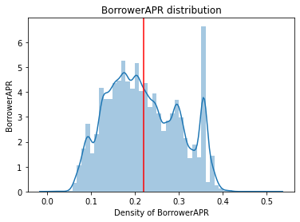

```python
sb.distplot(df['BorrowerAPR']).set_title("BorrowerAPR distribution");
plt.axvline(x=df['BorrowerAPR'].mean(), color='r')
plt.ylabel('BorrowerAPR')
plt.xlabel('Density of BorrowerAPR')
print(df['BorrowerAPR'].mean())
```

**Observation**: The mean of borrowerAPR be 0.218827655909788. Here is a high density around 0.36.

**BorrowerRate**

How are BorrowerRate distributed?

```
0.1927640577687518
```

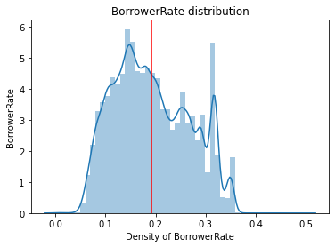

```python
ax = fig.add_axes([.0, .0, 2, 1.3])
sb.distplot(df['BorrowerRate']).set_title("BorrowerRate distribution");
plt.axvline(x=df['BorrowerRate'].mean(), color='r')
plt.ylabel('BorrowerRate')
plt.xlabel('Density of BorrowerRate')
print(df['BorrowerRate'].mean())
```

**Observation**: The mean of borrower rate be 0.1927640577687518. Here is a high density around 0.3.

The variable that may affect loan’s outcome status and borrower’s APR or interest rate:

**BorrowerState**, **Occupation**, **EmploymentStatus**, **EmploymentStatusDuration**, **DebtToIncomeRatio**, **StatedMonthlyIncome**, **MonthlyLoanPayment**, **Investors**.

**BorrowerState**

How are BorrowerState distributed?

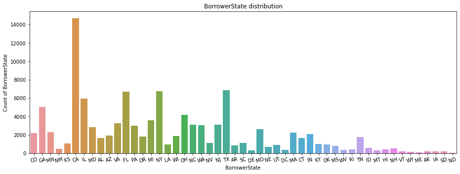

```python
fig = plt.figure()
ax = fig.add_axes([.0, .0, 2, 1])
sb.countplot(data=df, x='BorrowerState').set_title("BorrowerState distribution");
ax.set_xlabel('BorrowerState')
ax.set_ylabel('Count of BorrowerState')
plt.xticks(rotation=15);
```

**Observation**: The most loan borrower state is **CA**, about 1/8 of the total amount. We have 5 other states have large amount of loan.

**Occupation**

How are occupation distributed?

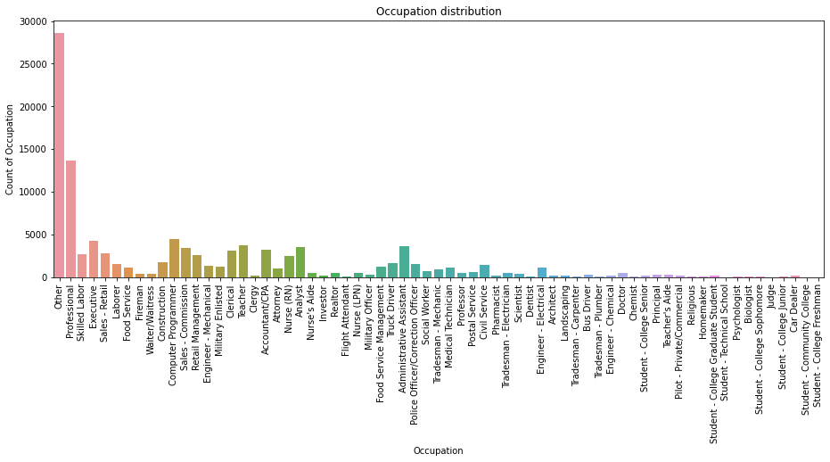

```python
fig = plt.figure()
ax = fig.add_axes([.0, .0, 2, 1])
sb.countplot(data=df, x='Occupation').set_title("Occupation distribution");
ax.set_xlabel('Occupation')
ax.set_ylabel('Count of Occupation')
plt.xticks(rotation=90);
```

```python
df['Occupation'].describe()
```

```
count     110349
unique        67
top        Other
freq       28617
Name: Occupation, dtype: object
```

```python
df['Occupation'].value_counts()
```

```
Other                          28617
Professional                   13628
Computer Programmer             4478
Executive                       4311
Teacher                         3759
                               ...
Dentist                           68
Student - College Freshman        41
Student - Community College       28
Judge                             22
Student - Technical School        16
Name: Occupation, Length: 67, dtype: int64
```

**Observation**: The most loan occupation is **other**, then is **professional**. However the category **other** may not be useful, meanwhile the other categories are too diverse, **occupation** may not be very useful in our research.

**EmploymentStatus**

How are EmploymentStatus distributed?

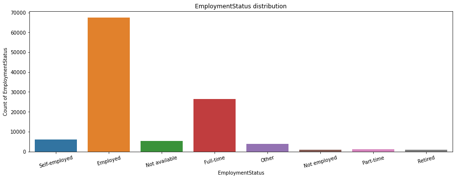

```python
fig = plt.figure()
ax = fig.add_axes([.0, .0, 2, 1])
sb.countplot(data=df, x='EmploymentStatus').set_title("EmploymentStatus distribution");
ax.set_xlabel('EmploymentStatus')
ax.set_ylabel('Count of EmploymentStatus')
plt.xticks(rotation=15);
```

```
(-1.100618642142316,
 1.1447913107253251,
 -1.1308785503628132,
 1.114531402504828)
```

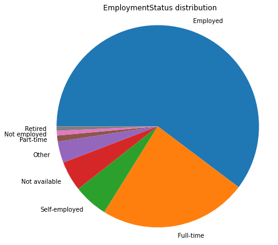

```python
fig = plt.figure()
ax = fig.add_axes([.0, .0, 2, 1.3])
sorted_counts = df['EmploymentStatus'].value_counts()

plt.pie(sorted_counts, labels = sorted_counts.index, startangle = 180, counterclock = False);
plt.title('EmploymentStatus distribution')
plt.axis('square')
```

**Observation**: The most employment status is **employed**, then is **full-time**. More than 50% are employed.

**EmploymentStatusDuration**

How are EmploymentStatusDuration distributed?

```
96.07158175934984
```

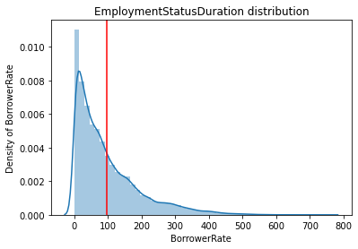

```python
sb.distplot(df['EmploymentStatusDuration']).set_title("EmploymentStatusDuration distribution");
plt.xlabel('BorrowerRate')
plt.ylabel('Density of BorrowerRate')
plt.axvline(x=df['EmploymentStatusDuration'].mean(), color='r')
print(df['EmploymentStatusDuration'].mean())
```

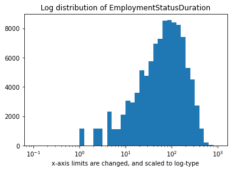

```python
np.log10(df['EmploymentStatusDuration'].describe())

bins = 10 ** np.arange(-1, 3+0.1, 0.1)
plt.hist(data=df, x='EmploymentStatusDuration', bins=bins);
plt.title('Log distribution of EmploymentStatusDuration')
plt.xscale('log')
plt.xlabel('x-axis limits are changed, and scaled to log-type')
```

**Observation**: Employment status duration is a right-skewed distribution.

**DebtToIncomeRatio**

How are DebtToIncomeRatio distributed?

```
0.2759466040063403
```

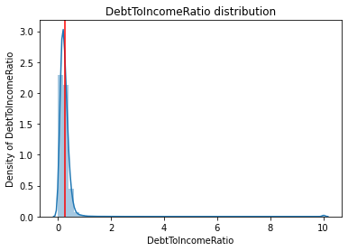

```python
sb.distplot(df['DebtToIncomeRatio']).set_title("DebtToIncomeRatio distribution");
plt.xlabel('DebtToIncomeRatio')
plt.ylabel('Density of DebtToIncomeRatio')
plt.axvline(x=df['DebtToIncomeRatio'].mean(), color='r')
print(df['DebtToIncomeRatio'].mean())
```

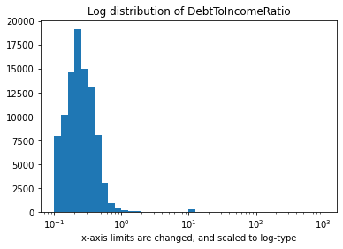

```python
np.log10(df['DebtToIncomeRatio'].describe())

bins = 10 ** np.arange(-1, 3+0.1, 0.1)
plt.hist(data=df, x='DebtToIncomeRatio', bins=bins);
plt.xscale('log')
plt.title('Log distribution of DebtToIncomeRatio')
plt.xlabel('x-axis limits are changed, and scaled to log-type')
```

**Observation:**: Debt to income ratio is a highly right-skewed distribution.

**StatedMonthlyIncome**

How are StatedMonthlyIncome distributed?

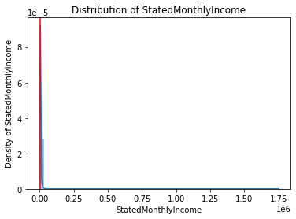

```python
sb.distplot(df['StatedMonthlyIncome'])
plt.xlabel('StatedMonthlyIncome')
plt.ylabel('Density of StatedMonthlyIncome')
plt.title('Distribution of StatedMonthlyIncome')
plt.axvline(x=df['StatedMonthlyIncome'].mean(), color='r')
```

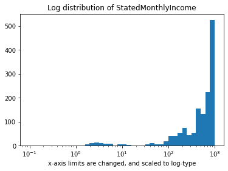

```python
np.log10(df['StatedMonthlyIncome'].describe())

bins = 10 ** np.arange(-1, 3+0.1, 0.1)
plt.hist(data=df, x='StatedMonthlyIncome', bins=bins);

plt.xscale('log')
plt.title('Log distribution of StatedMonthlyIncome')
plt.xlabel('x-axis limits are changed, and scaled to log-type')
```

**Observation:** Stated monthly income is a right-skewed distribution.

**MonthlyLoanPayment**

How are MonthlyLoanPayment distributed?

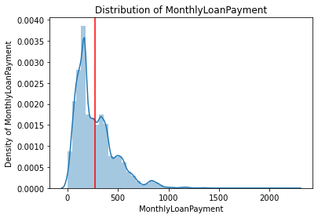

```python
sb.distplot(df['MonthlyLoanPayment'])
plt.xlabel('MonthlyLoanPayment')
plt.ylabel('Density of MonthlyLoanPayment')
plt.title('Distribution of MonthlyLoanPayment')
plt.axvline(x=df['MonthlyLoanPayment'].mean(), color='r')
```

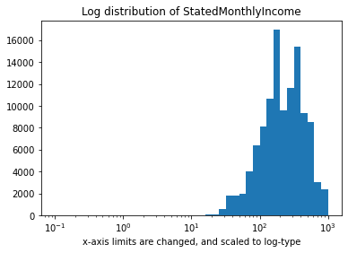

```python
np.log10(df['MonthlyLoanPayment'].describe())

bins = 10 ** np.arange(-1, 3+0.1, 0.1)
plt.hist(data=df, x='MonthlyLoanPayment', bins=bins);

plt.xscale('log')
plt.title('Log distribution of StatedMonthlyIncome')
plt.xlabel('x-axis limits are changed, and scaled to log-type')
```

**Observation:** Monthly loan payment is a right-skewed distribution.

**Investors**

How are Investors distributed?

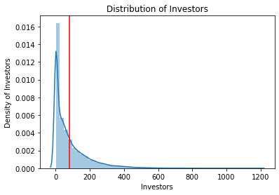

```python
sb.distplot(df['Investors'])
plt.axvline(x=df['Investors'].mean(), color='r')
plt.xlabel('Investors')
plt.ylabel('Density of Investors')
plt.title('Distribution of Investors')
```

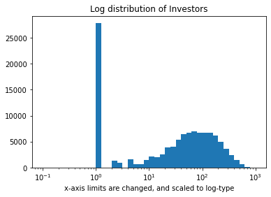

```python
np.log10(df['Investors'].describe())

bins = 10 ** np.arange(-1, 3+0.1, 0.1)
plt.hist(data=df, x='Investors', bins=bins);

plt.xscale('log')
plt.title('Log distribution of Investors')
plt.xlabel('x-axis limits are changed, and scaled to log-type')
```

**Observation:** Investors is a right-skewed distribution.

## Bivariate Exploration

Main variable of interest:

- LoanStatus(loan’s outcome)
- BorrowerAPR
- BorrowerRate

**LoanStatus vs BorrowerState:**

Are there relationship between loan status and borrower state? Are there states that have unique behaviour of load status?

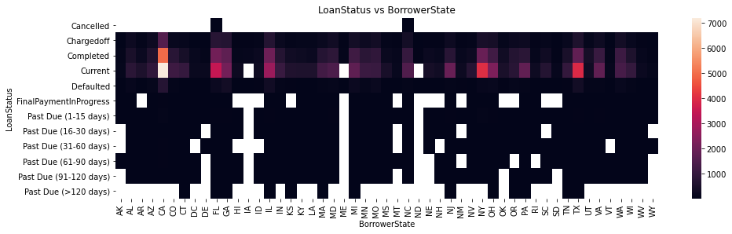

```python
fig = plt.figure()
ax = fig.add_axes([.0, .0, 2, 0.8])
ct_counts = df.groupby(['LoanStatus', 'BorrowerState']).size()
ct_counts = ct_counts.reset_index(name='count')
ct_counts = ct_counts.pivot(index = 'LoanStatus', columns = 'BorrowerState', values = 'count')

sb.heatmap(ct_counts).set_title("LoanStatus vs BorrowerState")
```

```python
df_group_pastDue = df.copy()
df_group_pastDue.loc[df_group_pastDue['LoanStatus'].str[:4] == 'Past', 'LoanStatus'] = 'Past Due'
```

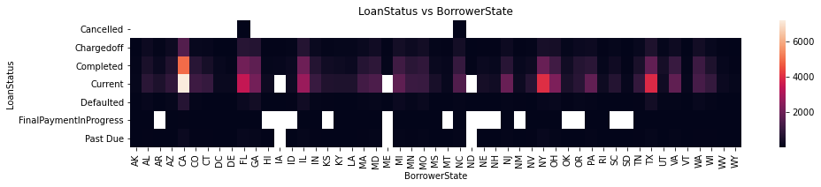

```python
fig = plt.figure()
ax = fig.add_axes([.0, .0, 2, 0.5])
ct_counts = df_group_pastDue.groupby(['LoanStatus', 'BorrowerState']).size()
ct_counts = ct_counts.reset_index(name='count')
ct_counts = ct_counts.pivot(index = 'LoanStatus', columns = 'BorrowerState', values = 'count')

sb.heatmap(ct_counts).set_title("LoanStatus vs BorrowerState")
```

**Observation:**

We have the only few coloured blocks are

- Current + CA
- Completed + CA
- Current + FL
- Current + NY
- Current + TX

We also notice that, 1/8 of data are CA and 50% of the data are current. We take a closer look to past due section, since they are all black.

```python
df_pastDue = df.copy()

df_pastDue.drop(df_pastDue[df_pastDue['LoanStatus'].str[:4] != 'Past'].index, inplace = True)
df_pastDue.loc[df_pastDue['LoanStatus'].str[:4] == 'Past', 'LoanStatus'] = 'Past Due'
```

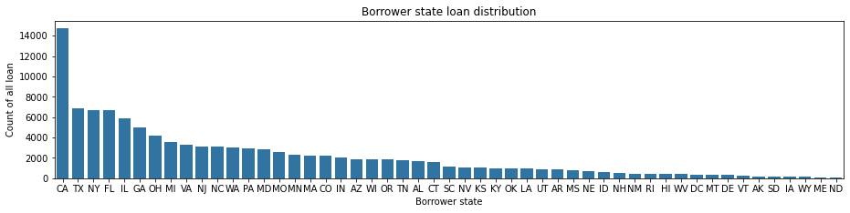

```python
freq = df['BorrowerState'].value_counts()

pastDue_order = freq.index
fig = plt.figure()
ax = fig.add_axes([.0, .0, 2, 0.6])

sb.countplot(data=df, x='BorrowerState', color=base_color, order=pastDue_order);
ax.set_xlabel('Borrower state')
ax.set_ylabel('Count of all loan')
ax.set_title('Borrower state loan distribution')
```

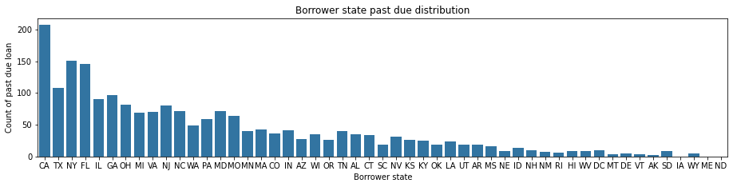

```python
fig = plt.figure()
ax = fig.add_axes([.0, .0, 2, 0.6])

sb.countplot(data=df_pastDue, x='BorrowerState', color=base_color, order=pastDue_order);
ax.set_xlabel('Borrower state')
ax.set_ylabel('Count of past due loan')
ax.set_title('Borrower state past due distribution')
```

```python
df_Comp = df.copy()

df_Comp.drop(df_Comp[df_Comp['LoanStatus'].str[:4] != 'Comp'].index, inplace = True)
```

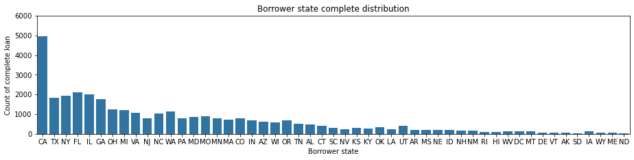

```python
fig = plt.figure()
ax = fig.add_axes([.0, .0, 2, 0.6])
sb.countplot(data=df_Comp, x='BorrowerState', color=base_color, order=pastDue_order);
ax.set(ylim=(0, 6000))
ax.set_xlabel('Borrower state')
ax.set_ylabel('Count of complete loan')
ax.set_title('Borrower state complete distribution')
```

**Observation:** There is no obvious relationship between borrowerState and LoanStatus. Mostly count are depending on population on loanstatus but not on borrowstate.

We see TX has a slightly lower past due loan rate,NY and FL have a slightly higher past due loan rate.

Also, TX has a slightly lower complete loan rate.

**LoanStatus vs BorrowerAPR**

How is the relationship between loan status and borrowerAPR, does different loan status affect borrower APR?

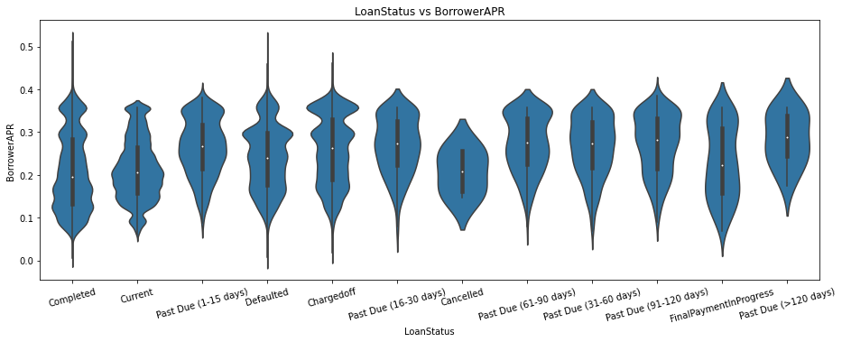

```python
fig = plt.figure()
ax = fig.add_axes([.0, .0, 2, 1])
sb.violinplot(data=df, x='LoanStatus', y='BorrowerAPR', color=base_color, innner=None)
plt.xticks(rotation=15);
ax.set_xlabel('LoanStatus')
ax.set_ylabel('BorrowerAPR')
ax.set_title('LoanStatus vs BorrowerAPR')
```

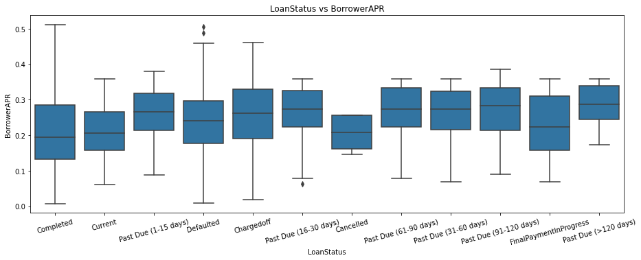

```python
fig = plt.figure()
ax = fig.add_axes([.0, .0, 2, 1])

sb.boxplot(data=df, x='LoanStatus', y='BorrowerAPR', color=base_color)
plt.xticks(rotation=15);
ax.set_xlabel('LoanStatus')
ax.set_ylabel('BorrowerAPR')
ax.set_title('LoanStatus vs BorrowerAPR')
```

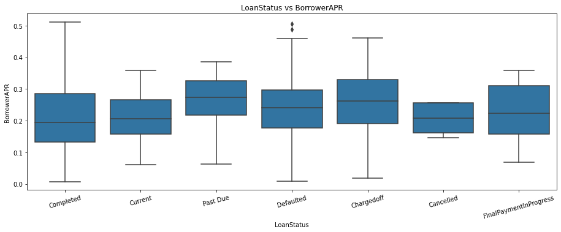

```python
fig = plt.figure()
ax = fig.add_axes([.0, .0, 2, 1])

sb.boxplot(data=df_group_pastDue, x='LoanStatus', y='BorrowerAPR', color=base_color)
plt.xticks(rotation=15);
ax.set_xlabel('LoanStatus')
ax.set_ylabel('BorrowerAPR')
ax.set_title('LoanStatus vs BorrowerAPR')
```

**Observation:** We have completed loanstatus have lowerest borrowerAPR. PastDue have the highest borrowerAPR.

Completed loan status has the largest range of APR and cancelled loan status has the smallest range of APR.

**LoanStatus vs BorrowerRate**

How is the relationship between loan status and borrower rate?

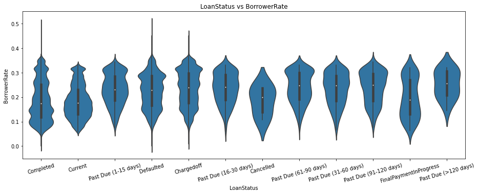

```python
fig = plt.figure()
ax = fig.add_axes([.0, .0, 2, 1])
base_color = sb.color_palette()[0]

sb.violinplot(data=df, x='LoanStatus', y='BorrowerRate', color=base_color, innner=None)
ax.set_xlabel('LoanStatus')
ax.set_ylabel('BorrowerRate')
ax.set_title('LoanStatus vs BorrowerRate')
plt.xticks(rotation=15);
```

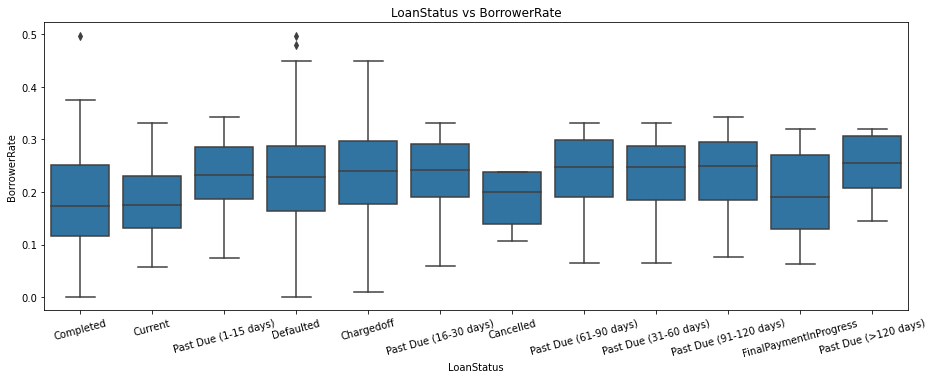

```python
fig = plt.figure()
ax = fig.add_axes([.0, .0, 2, 1])

sb.boxplot(data=df, x='LoanStatus', y='BorrowerRate', color=base_color)
ax.set_xlabel('LoanStatus')
ax.set_ylabel('BorrowerRate')
ax.set_title('LoanStatus vs BorrowerRate')
plt.xticks(rotation=15);
```

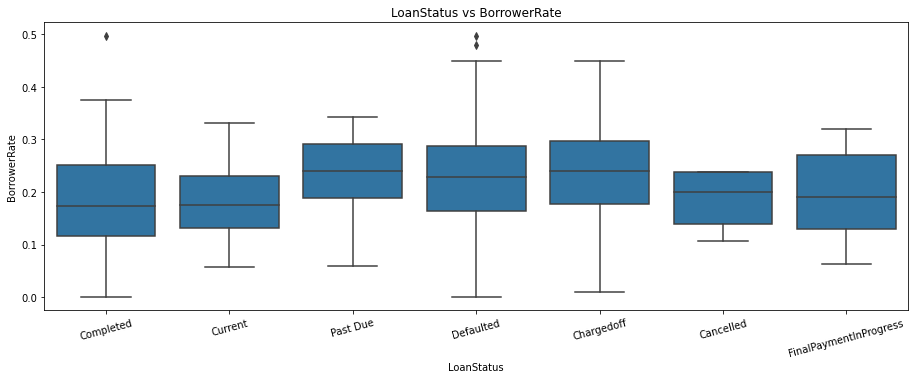

```python
fig = plt.figure()
ax = fig.add_axes([.0, .0, 2, 1])

sb.boxplot(data=df_group_pastDue, x='LoanStatus', y='BorrowerRate', color=base_color)
ax.set_xlabel('LoanStatus')
ax.set_ylabel('BorrowerRate')
ax.set_title('LoanStatus vs BorrowerRate')
plt.xticks(rotation=15);
```

**Observation:** We have completed loanstatus have lowerest borrower rate. PastDue have the highest borrower rate, which is same as borrower rate.

**LoanStatus vs EmploymentStatus**